# Risk Factor Analysis

## Outcome Variable

**Outcome Variable:** haz

## Predictor Variables

**Intervention Variable:** enstunt

**Adjustment Set:**

- arm
- sex
- W_mage
- meducyrs
- feducyrs
- vagbrth
- single
- brthmon
- W_parity
- impsan
- delta_W_mage
- delta_meducyrs
- delta_feducyrs
- delta_vagbrth
- delta_single
- delta_brthmon
- delta_W_parity
- delta_impsan

## Stratifying Variables

The analysis was stratified on these variable(s):

- agecat
- studyid
- country

## Data Summary

| agecat | studyid | country | enstunt | n_cell | n | outcome_variable |
| --- | --- | --- | --- | --- | --- | --- |
| Birth | CMC-V-BCS-2002 | INDIA | 0 | 75 | 92 | haz |
| Birth | CMC-V-BCS-2002 | INDIA | 1 | 17 | 92 | haz |
| Birth | CMIN | BANGLADESH | 0 | 17 | 26 | haz |
| Birth | CMIN | BANGLADESH | 1 | 9 | 26 | haz |
| Birth | COHORTS | GUATEMALA | 0 | 802 | 852 | haz |
| Birth | COHORTS | GUATEMALA | 1 | 50 | 852 | haz |
| Birth | COHORTS | INDIA | 0 | 5848 | 6640 | haz |
| Birth | COHORTS | INDIA | 1 | 792 | 6640 | haz |
| Birth | COHORTS | PHILIPPINES | 0 | 2863 | 3050 | haz |
| Birth | COHORTS | PHILIPPINES | 1 | 187 | 3050 | haz |
| Birth | CONTENT | PERU | 0 | 2 | 2 | haz |
| Birth | CONTENT | PERU | 1 | 0 | 2 | haz |
| Birth | EE | PAKISTAN | 0 | 140 | 240 | haz |
| Birth | EE | PAKISTAN | 1 | 100 | 240 | haz |
| Birth | GMS-Nepal | NEPAL | 0 | 574 | 696 | haz |
| Birth | GMS-Nepal | NEPAL | 1 | 122 | 696 | haz |
| Birth | IRC | INDIA | 0 | 343 | 388 | haz |
| Birth | IRC | INDIA | 1 | 45 | 388 | haz |
| Birth | JiVitA-3 | BANGLADESH | 0 | 15068 | 22455 | haz |
| Birth | JiVitA-3 | BANGLADESH | 1 | 7387 | 22455 | haz |
| Birth | JiVitA-4 | BANGLADESH | 0 | 1966 | 2823 | haz |
| Birth | JiVitA-4 | BANGLADESH | 1 | 857 | 2823 | haz |
| Birth | Keneba | GAMBIA | 0 | 1460 | 1543 | haz |
| Birth | Keneba | GAMBIA | 1 | 83 | 1543 | haz |
| Birth | MAL-ED | BANGLADESH | 0 | 187 | 231 | haz |
| Birth | MAL-ED | BANGLADESH | 1 | 44 | 231 | haz |
| Birth | MAL-ED | BRAZIL | 0 | 56 | 65 | haz |
| Birth | MAL-ED | BRAZIL | 1 | 9 | 65 | haz |
| Birth | MAL-ED | INDIA | 0 | 37 | 47 | haz |
| Birth | MAL-ED | INDIA | 1 | 10 | 47 | haz |

[output cut: 134 more lines]

The following strata were considered:

- agecat: 24 months, studyid: CMC-V-BCS-2002, country: INDIA
- agecat: 24 months, studyid: CMIN, country: BANGLADESH
- agecat: 24 months, studyid: COHORTS, country: GUATEMALA
- agecat: 24 months, studyid: COHORTS, country: INDIA
- agecat: 24 months, studyid: COHORTS, country: PHILIPPINES
- agecat: 24 months, studyid: CONTENT, country: PERU
- agecat: 24 months, studyid: EE, country: PAKISTAN
- agecat: 24 months, studyid: GMS-Nepal, country: NEPAL
- agecat: 24 months, studyid: IRC, country: INDIA
- agecat: 24 months, studyid: JiVitA-3, country: BANGLADESH
- agecat: 24 months, studyid: JiVitA-4, country: BANGLADESH
- agecat: 24 months, studyid: Keneba, country: GAMBIA
- agecat: 24 months, studyid: LCNI-5, country: MALAWI
- agecat: 24 months, studyid: MAL-ED, country: BANGLADESH
- agecat: 24 months, studyid: MAL-ED, country: BRAZIL
- agecat: 24 months, studyid: MAL-ED, country: INDIA
- agecat: 24 months, studyid: MAL-ED, country: NEPAL
- agecat: 24 months, studyid: MAL-ED, country: PERU
- agecat: 24 months, studyid: MAL-ED, country: SOUTH AFRICA
- agecat: 24 months, studyid: MAL-ED, country: TANZANIA, UNITED REPUBLIC OF
- agecat: 24 months, studyid: NIH-Birth, country: BANGLADESH
- agecat: 24 months, studyid: NIH-Crypto, country: BANGLADESH
- agecat: 24 months, studyid: PROBIT, country: BELARUS
- agecat: 24 months, studyid: PROVIDE, country: BANGLADESH
- agecat: 24 months, studyid: TanzaniaChild2, country: TANZANIA, UNITED REPUBLIC OF
- agecat: 24 months, studyid: ZVITAMBO, country: ZIMBABWE
- agecat: 6 months, studyid: CMC-V-BCS-2002, country: INDIA
- agecat: 6 months, studyid: CMIN, country: BANGLADESH
- agecat: 6 months, studyid: COHORTS, country: GUATEMALA
- agecat: 6 months, studyid: COHORTS, country: INDIA
- agecat: 6 months, studyid: COHORTS, country: PHILIPPINES
- agecat: 6 months, studyid: CONTENT, country: PERU
- agecat: 6 months, studyid: EE, country: PAKISTAN
- agecat: 6 months, studyid: GMS-Nepal, country: NEPAL
- agecat: 6 months, studyid: Guatemala BSC, country: GUATEMALA
- agecat: 6 months, studyid: IRC, country: INDIA
- agecat: 6 months, studyid: JiVitA-3, country: BANGLADESH
- agecat: 6 months, studyid: JiVitA-4, country: BANGLADESH
- agecat: 6 months, studyid: Keneba, country: GAMBIA
- agecat: 6 months, studyid: LCNI-5, country: MALAWI
- agecat: 6 months, studyid: MAL-ED, country: BANGLADESH
- agecat: 6 months, studyid: MAL-ED, country: BRAZIL
- agecat: 6 months, studyid: MAL-ED, country: INDIA
- agecat: 6 months, studyid: MAL-ED, country: NEPAL
- agecat: 6 months, studyid: MAL-ED, country: PERU
- agecat: 6 months, studyid: MAL-ED, country: SOUTH AFRICA
- agecat: 6 months, studyid: MAL-ED, country: TANZANIA, UNITED REPUBLIC OF
- agecat: 6 months, studyid: NIH-Birth, country: BANGLADESH
- agecat: 6 months, studyid: NIH-Crypto, country: BANGLADESH
- agecat: 6 months, studyid: PROBIT, country: BELARUS
- agecat: 6 months, studyid: PROVIDE, country: BANGLADESH
- agecat: 6 months, studyid: ResPak, country: PAKISTAN
- agecat: 6 months, studyid: SAS-CompFeed, country: INDIA
- agecat: 6 months, studyid: SAS-FoodSuppl, country: INDIA
- agecat: 6 months, studyid: TanzaniaChild2, country: TANZANIA, UNITED REPUBLIC OF
- agecat: 6 months, studyid: ZVITAMBO, country: ZIMBABWE
- agecat: Birth, studyid: CMC-V-BCS-2002, country: INDIA
- agecat: Birth, studyid: CMIN, country: BANGLADESH
- agecat: Birth, studyid: COHORTS, country: GUATEMALA
- agecat: Birth, studyid: COHORTS, country: INDIA
- agecat: Birth, studyid: COHORTS, country: PHILIPPINES
- agecat: Birth, studyid: CONTENT, country: PERU
- agecat: Birth, studyid: EE, country: PAKISTAN
- agecat: Birth, studyid: GMS-Nepal, country: NEPAL
- agecat: Birth, studyid: IRC, country: INDIA
- agecat: Birth, studyid: JiVitA-3, country: BANGLADESH
- agecat: Birth, studyid: JiVitA-4, country: BANGLADESH
- agecat: Birth, studyid: Keneba, country: GAMBIA
- agecat: Birth, studyid: MAL-ED, country: BANGLADESH
- agecat: Birth, studyid: MAL-ED, country: BRAZIL
- agecat: Birth, studyid: MAL-ED, country: INDIA
- agecat: Birth, studyid: MAL-ED, country: NEPAL
- agecat: Birth, studyid: MAL-ED, country: PERU
- agecat: Birth, studyid: MAL-ED, country: SOUTH AFRICA
- agecat: Birth, studyid: MAL-ED, country: TANZANIA, UNITED REPUBLIC OF
- agecat: Birth, studyid: NIH-Birth, country: BANGLADESH
- agecat: Birth, studyid: NIH-Crypto, country: BANGLADESH
- agecat: Birth, studyid: PROBIT, country: BELARUS
- agecat: Birth, studyid: PROVIDE, country: BANGLADESH
- agecat: Birth, studyid: ResPak, country: PAKISTAN
- agecat: Birth, studyid: SAS-CompFeed, country: INDIA
- agecat: Birth, studyid: ZVITAMBO, country: ZIMBABWE

### Dropped Strata

Some strata were dropped due to rare outcomes:

- agecat: Birth, studyid: CONTENT, country: PERU
- agecat: Birth, studyid: MAL-ED, country: NEPAL
- agecat: 24 months, studyid: TanzaniaChild2, country: TANZANIA, UNITED REPUBLIC OF

## Methods Detail

We’re interested in the causal parameters $E[Y_a]$ for all values of $a \in \mathcal{A}$. These parameters represent the mean outcome if, possibly contrary to fact, we intervened to set all units to have $A=a$. Under the randomization and positivity assumptions, these are identified by the statistical parameters $\psi_a=E_W[E_{Y|A,W}(Y|A=a,W)]$. In addition, we’re interested in the mean of $Y$, $E[Y]$ under no intervention (the observed mean). We will estimate these parameters by using SuperLearner to fit the relevant likelihood factors – $E_{Y|A,W}(Y|A=a,W)$ and $p(A=a|W)$, and then updating our likelihood fit using a joint TMLE.

For unadjusted analyses ($W=\{\}$), initial likelihoods were estimated using Lrnr_glm to estimate the simple $E(Y|A)$ and Lrnr_mean to estimate $p(A)$. For adjusted analyses, a small library containing Lrnr_glmnet, Lrnr_xgboost, and Lrnr_mean was used.

Having estimated these parameters, we will then use the delta method to estimate relative risks and attributable risks relative to a prespecified baseline level of $A$.

# Results Detail

## Results Plots

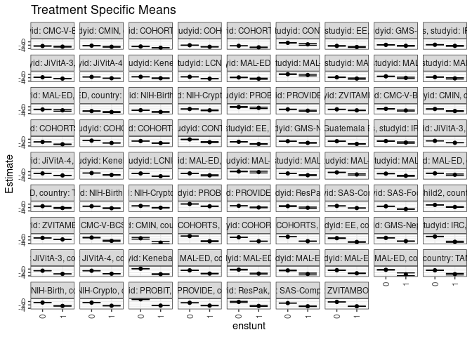

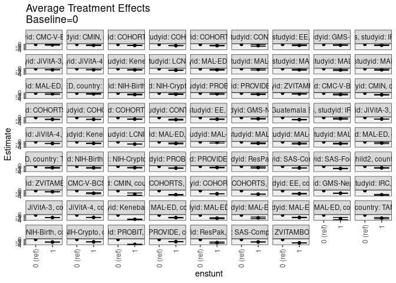

[figure not shown]

## Results Table

### Parameter: TSM

| agecat | studyid | country | intervention_level | baseline_level | estimate | ci_lower | ci_upper |
| --- | --- | --- | --- | --- | --- | --- | --- |
| Birth | CMC-V-BCS-2002 | INDIA | 0 | NA | -0.5793051 | -0.7429214 | -0.4156888 |
| Birth | CMC-V-BCS-2002 | INDIA | 1 | NA | -2.5030814 | -2.8505853 | -2.1555775 |
| Birth | CMIN | BANGLADESH | 0 | NA | -0.9811765 | -1.4828326 | -0.4795203 |
| Birth | CMIN | BANGLADESH | 1 | NA | -3.5811111 | -4.2641379 | -2.8980843 |
| Birth | COHORTS | GUATEMALA | 0 | NA | 0.3085669 | 0.2369424 | 0.3801914 |
| Birth | COHORTS | GUATEMALA | 1 | NA | -2.7247558 | -2.9776177 | -2.4718939 |
| Birth | COHORTS | INDIA | 0 | NA | -0.3941340 | -0.4177401 | -0.3705280 |
| Birth | COHORTS | INDIA | 1 | NA | -2.7111454 | -2.7580719 | -2.6642189 |
| Birth | COHORTS | PHILIPPINES | 0 | NA | -0.0883565 | -0.1217389 | -0.0549741 |
| Birth | COHORTS | PHILIPPINES | 1 | NA | -2.7032393 | -2.8032555 | -2.6032232 |
| Birth | EE | PAKISTAN | 0 | NA | -0.9214425 | -1.0895564 | -0.7533285 |
| Birth | EE | PAKISTAN | 1 | NA | -3.1624429 | -3.3492102 | -2.9756755 |
| Birth | GMS-Nepal | NEPAL | 0 | NA | -0.7470112 | -0.8131444 | -0.6808780 |
| Birth | GMS-Nepal | NEPAL | 1 | NA | -2.6773448 | -2.7939018 | -2.5607879 |
| Birth | IRC | INDIA | 0 | NA | 0.0466557 | -0.0915952 | 0.1849065 |
| Birth | IRC | INDIA | 1 | NA | -3.0479492 | -3.3645239 | -2.7313744 |
| Birth | JiVitA-3 | BANGLADESH | 0 | NA | -0.9715210 | -0.9848994 | -0.9581425 |
| Birth | JiVitA-3 | BANGLADESH | 1 | NA | -2.8511834 | -2.8707519 | -2.8316150 |
| Birth | JiVitA-4 | BANGLADESH | 0 | NA | -0.9835682 | -1.0222514 | -0.9448851 |
| Birth | JiVitA-4 | BANGLADESH | 1 | NA | -2.7599271 | -2.8113936 | -2.7084607 |
| Birth | Keneba | GAMBIA | 0 | NA | 0.2043705 | 0.1508181 | 0.2579230 |
| Birth | Keneba | GAMBIA | 1 | NA | -3.0263880 | -3.2646646 | -2.7881115 |
| Birth | MAL-ED | BANGLADESH | 0 | NA | -0.7491692 | -0.8554332 | -0.6429051 |
| Birth | MAL-ED | BANGLADESH | 1 | NA | -2.6828435 | -2.8527077 | -2.5129792 |
| Birth | MAL-ED | BRAZIL | 0 | NA | -0.3512500 | -0.5701451 | -0.1323549 |
| Birth | MAL-ED | BRAZIL | 1 | NA | -2.6966667 | -2.9574559 | -2.4358775 |
| Birth | MAL-ED | INDIA | 0 | NA | -0.8041651 | -1.0093709 | -0.5989592 |
| Birth | MAL-ED | INDIA | 1 | NA | -2.8947490 | -3.4189587 | -2.3705393 |
| Birth | MAL-ED | PERU | 0 | NA | -0.6797502 | -0.7815448 | -0.5779557 |
| Birth | MAL-ED | PERU | 1 | NA | -2.4904347 | -2.6427085 | -2.3381610 |

[output cut: 128 more lines]

### Parameter: E(Y)

| agecat | studyid | country | intervention_level | baseline_level | estimate | ci_lower | ci_upper |
| --- | --- | --- | --- | --- | --- | --- | --- |
| Birth | CMC-V-BCS-2002 | INDIA | NA | NA | -0.9611957 | -1.1776967 | -0.7446946 |
| Birth | CMIN | BANGLADESH | NA | NA | -1.8811538 | -2.5124807 | -1.2498270 |
| Birth | COHORTS | GUATEMALA | NA | NA | 0.1297300 | 0.0458017 | 0.2136584 |
| Birth | COHORTS | INDIA | NA | NA | -0.6698961 | -0.6980556 | -0.6417365 |
| Birth | COHORTS | PHILIPPINES | NA | NA | -0.2490492 | -0.2880580 | -0.2100404 |
| Birth | EE | PAKISTAN | NA | NA | -1.8608750 | -2.0482045 | -1.6735455 |
| Birth | GMS-Nepal | NEPAL | NA | NA | -1.0851580 | -1.1651811 | -1.0051350 |
| Birth | IRC | INDIA | NA | NA | -0.3080412 | -0.4687931 | -0.1472894 |
| Birth | JiVitA-3 | BANGLADESH | NA | NA | -1.5894148 | -1.6086362 | -1.5701935 |
| Birth | JiVitA-4 | BANGLADESH | NA | NA | -1.5232908 | -1.5723277 | -1.4742539 |
| Birth | Keneba | GAMBIA | NA | NA | 0.0308036 | -0.0328378 | 0.0944451 |
| Birth | MAL-ED | BANGLADESH | NA | NA | -1.1180952 | -1.2525408 | -0.9836496 |
| Birth | MAL-ED | BRAZIL | NA | NA | -0.6760000 | -0.9521457 | -0.3998543 |
| Birth | MAL-ED | INDIA | NA | NA | -1.2036170 | -1.4976814 | -0.9095527 |
| Birth | MAL-ED | PERU | NA | NA | -0.8827897 | -1.0001058 | -0.7654736 |
| Birth | MAL-ED | SOUTH AFRICA | NA | NA | -0.6317073 | -0.8249555 | -0.4384591 |
| Birth | MAL-ED | TANZANIA, UNITED REPUBLIC OF | NA | NA | -1.1556000 | -1.3655361 | -0.9456639 |
| Birth | NIH-Birth | BANGLADESH | NA | NA | -0.9310197 | -1.0197391 | -0.8423003 |
| Birth | NIH-Crypto | BANGLADESH | NA | NA | -0.9094945 | -0.9809370 | -0.8380521 |
| Birth | PROBIT | BELARUS | NA | NA | 1.3114417 | 1.1524752 | 1.4704082 |
| Birth | PROVIDE | BANGLADESH | NA | NA | -0.8851020 | -0.9601332 | -0.8100709 |
| Birth | ResPak | PAKISTAN | NA | NA | -0.9800000 | -1.4086438 | -0.5513562 |
| Birth | SAS-CompFeed | INDIA | NA | NA | -1.4314217 | -1.5099245 | -1.3529189 |
| Birth | ZVITAMBO | ZIMBABWE | NA | NA | -0.5002724 | -0.5208163 | -0.4797285 |
| 6 months | CMC-V-BCS-2002 | INDIA | NA | NA | -1.4234508 | -1.5645974 | -1.2823042 |
| 6 months | CMIN | BANGLADESH | NA | NA | -1.7844376 | -1.9222926 | -1.6465825 |
| 6 months | COHORTS | GUATEMALA | NA | NA | -1.8157336 | -1.8837688 | -1.7476985 |
| 6 months | COHORTS | INDIA | NA | NA | -0.9968455 | -1.0246180 | -0.9690730 |
| 6 months | COHORTS | PHILIPPINES | NA | NA | -1.1405724 | -1.1824954 | -1.0986493 |
| 6 months | CONTENT | PERU | NA | NA | -0.2785256 | -0.4098735 | -0.1471776 |
| 6 months | EE | PAKISTAN | NA | NA | -2.0835567 | -2.2027557 | -1.9643578 |
| 6 months | GMS-Nepal | NEPAL | NA | NA | -1.3508392 | -1.4290633 | -1.2726152 |
| 6 months | Guatemala BSC | GUATEMALA | NA | NA | -1.5619008 | -1.6727702 | -1.4510313 |
| 6 months | IRC | INDIA | NA | NA | -1.2344062 | -1.3658524 | -1.1029600 |
| 6 months | JiVitA-3 | BANGLADESH | NA | NA | -1.3130932 | -1.3362359 | -1.2899505 |
| 6 months | JiVitA-4 | BANGLADESH | NA | NA | -1.3447940 | -1.3820261 | -1.3075620 |
| 6 months | Keneba | GAMBIA | NA | NA | -0.9041369 | -0.9513363 | -0.8569376 |
| 6 months | LCNI-5 | MALAWI | NA | NA | -1.6601907 | -1.7297701 | -1.5906113 |
| 6 months | MAL-ED | BANGLADESH | NA | NA | -1.2049931 | -1.3222136 | -1.0877726 |
| 6 months | MAL-ED | BRAZIL | NA | NA | 0.0475758 | -0.0963508 | 0.1915023 |
| 6 months | MAL-ED | INDIA | NA | NA | -1.2115254 | -1.3298727 | -1.0931782 |
| 6 months | MAL-ED | NEPAL | NA | NA | -0.5615819 | -0.6741832 | -0.4489807 |
| 6 months | MAL-ED | PERU | NA | NA | -1.3236661 | -1.4316775 | -1.2156546 |
| 6 months | MAL-ED | SOUTH AFRICA | NA | NA | -1.0633202 | -1.1909180 | -0.9357224 |
| 6 months | MAL-ED | TANZANIA, UNITED REPUBLIC OF | NA | NA | -1.3687449 | -1.4907629 | -1.2467270 |
| 6 months | NIH-Birth | BANGLADESH | NA | NA | -1.4073821 | -1.4960598 | -1.3187043 |
| 6 months | NIH-Crypto | BANGLADESH | NA | NA | -1.1986783 | -1.2700937 | -1.1272630 |
| 6 months | PROBIT | BELARUS | NA | NA | 0.0980074 | 0.0062724 | 0.1897424 |
| 6 months | PROVIDE | BANGLADESH | NA | NA | -1.0916915 | -1.1661176 | -1.0172654 |
| 6 months | ResPak | PAKISTAN | NA | NA | -1.4314086 | -1.6374838 | -1.2253335 |
| 6 months | SAS-CompFeed | INDIA | NA | NA | -1.4018563 | -1.4810585 | -1.3226541 |
| 6 months | SAS-FoodSuppl | INDIA | NA | NA | -1.8986842 | -2.0118892 | -1.7854792 |
| 6 months | TanzaniaChild2 | TANZANIA, UNITED REPUBLIC OF | NA | NA | -0.5434389 | -0.5924056 | -0.4944722 |
| 6 months | ZVITAMBO | ZIMBABWE | NA | NA | -0.8679450 | -0.8935071 | -0.8423828 |
| 24 months | CMC-V-BCS-2002 | INDIA | NA | NA | -2.5588679 | -2.6583730 | -2.4593629 |
| 24 months | CMIN | BANGLADESH | NA | NA | -2.5109504 | -2.6361514 | -2.3857494 |
| 24 months | COHORTS | GUATEMALA | NA | NA | -2.9923738 | -3.0565851 | -2.9281626 |
| 24 months | COHORTS | INDIA | NA | NA | -2.1198201 | -2.1524299 | -2.0872104 |
| 24 months | COHORTS | PHILIPPINES | NA | NA | -2.4141145 | -2.4590818 | -2.3691473 |
| 24 months | CONTENT | PERU | NA | NA | -0.6868598 | -0.8388476 | -0.5348719 |
| 24 months | EE | PAKISTAN | NA | NA | -2.6699900 | -2.8138051 | -2.5261749 |
| 24 months | GMS-Nepal | NEPAL | NA | NA | -1.8874180 | -1.9728588 | -1.8019773 |
| 24 months | IRC | INDIA | NA | NA | -1.7987775 | -1.8923914 | -1.7051636 |
| 24 months | JiVitA-3 | BANGLADESH | NA | NA | -2.0136481 | -2.0413552 | -1.9859409 |
| 24 months | JiVitA-4 | BANGLADESH | NA | NA | -1.7807218 | -1.8162478 | -1.7451958 |
| 24 months | Keneba | GAMBIA | NA | NA | -1.5774356 | -1.6272400 | -1.5276311 |
| 24 months | LCNI-5 | MALAWI | NA | NA | -1.8861485 | -1.9671802 | -1.8051169 |
| 24 months | MAL-ED | BANGLADESH | NA | NA | -1.9783962 | -2.1050210 | -1.8517715 |
| 24 months | MAL-ED | BRAZIL | NA | NA | 0.0061144 | -0.1625850 | 0.1748138 |
| 24 months | MAL-ED | INDIA | NA | NA | -1.8861894 | -2.0110006 | -1.7613783 |
| 24 months | MAL-ED | NEPAL | NA | NA | -1.3075877 | -1.4270718 | -1.1881037 |
| 24 months | MAL-ED | PERU | NA | NA | -1.7524710 | -1.8736426 | -1.6312994 |
| 24 months | MAL-ED | SOUTH AFRICA | NA | NA | -1.6450595 | -1.7797240 | -1.5103950 |
| 24 months | MAL-ED | TANZANIA, UNITED REPUBLIC OF | NA | NA | -2.6455607 | -2.7807256 | -2.5103959 |
| 24 months | NIH-Birth | BANGLADESH | NA | NA | -2.2190579 | -2.3217459 | -2.1163699 |
| 24 months | NIH-Crypto | BANGLADESH | NA | NA | -1.4412646 | -1.5249156 | -1.3576135 |
| 24 months | PROBIT | BELARUS | NA | NA | -0.1442891 | -0.4253755 | 0.1367972 |
| 24 months | PROVIDE | BANGLADESH | NA | NA | -1.6024221 | -1.6857420 | -1.5191023 |
| 24 months | ZVITAMBO | ZIMBABWE | NA | NA | -1.6055701 | -1.6625562 | -1.5485840 |

### Parameter: ATE

| agecat | studyid | country | intervention_level | baseline_level | estimate | ci_lower | ci_upper |
| --- | --- | --- | --- | --- | --- | --- | --- |
| Birth | CMC-V-BCS-2002 | INDIA | 0 | 0 | 0.0000000 | 0.0000000 | 0.0000000 |
| Birth | CMC-V-BCS-2002 | INDIA | 1 | 0 | -1.9237763 | -2.3093845 | -1.5381681 |
| Birth | CMIN | BANGLADESH | 0 | 0 | 0.0000000 | 0.0000000 | 0.0000000 |
| Birth | CMIN | BANGLADESH | 1 | 0 | -2.5999346 | -3.4473923 | -1.7524770 |
| Birth | COHORTS | GUATEMALA | 0 | 0 | 0.0000000 | 0.0000000 | 0.0000000 |
| Birth | COHORTS | GUATEMALA | 1 | 0 | -3.0333227 | -3.2961853 | -2.7704602 |
| Birth | COHORTS | INDIA | 0 | 0 | 0.0000000 | 0.0000000 | 0.0000000 |
| Birth | COHORTS | INDIA | 1 | 0 | -2.3170113 | -2.3695637 | -2.2644590 |
| Birth | COHORTS | PHILIPPINES | 0 | 0 | 0.0000000 | 0.0000000 | 0.0000000 |
| Birth | COHORTS | PHILIPPINES | 1 | 0 | -2.6148828 | -2.7203635 | -2.5094021 |
| Birth | EE | PAKISTAN | 0 | 0 | 0.0000000 | 0.0000000 | 0.0000000 |
| Birth | EE | PAKISTAN | 1 | 0 | -2.2410004 | -2.4953291 | -1.9866718 |
| Birth | GMS-Nepal | NEPAL | 0 | 0 | 0.0000000 | 0.0000000 | 0.0000000 |
| Birth | GMS-Nepal | NEPAL | 1 | 0 | -1.9303336 | -2.0642938 | -1.7963735 |
| Birth | IRC | INDIA | 0 | 0 | 0.0000000 | 0.0000000 | 0.0000000 |
| Birth | IRC | INDIA | 1 | 0 | -3.0946048 | -3.4398245 | -2.7493852 |
| Birth | JiVitA-3 | BANGLADESH | 0 | 0 | 0.0000000 | 0.0000000 | 0.0000000 |
| Birth | JiVitA-3 | BANGLADESH | 1 | 0 | -1.8796625 | -1.9041743 | -1.8551507 |
| Birth | JiVitA-4 | BANGLADESH | 0 | 0 | 0.0000000 | 0.0000000 | 0.0000000 |
| Birth | JiVitA-4 | BANGLADESH | 1 | 0 | -1.7763589 | -1.8415644 | -1.7111534 |
| Birth | Keneba | GAMBIA | 0 | 0 | 0.0000000 | 0.0000000 | 0.0000000 |
| Birth | Keneba | GAMBIA | 1 | 0 | -3.2307586 | -3.4750468 | -2.9864704 |
| Birth | MAL-ED | BANGLADESH | 0 | 0 | 0.0000000 | 0.0000000 | 0.0000000 |
| Birth | MAL-ED | BANGLADESH | 1 | 0 | -1.9336743 | -2.1344944 | -1.7328542 |
| Birth | MAL-ED | BRAZIL | 0 | 0 | 0.0000000 | 0.0000000 | 0.0000000 |
| Birth | MAL-ED | BRAZIL | 1 | 0 | -2.3454167 | -2.6858959 | -2.0049374 |
| Birth | MAL-ED | INDIA | 0 | 0 | 0.0000000 | 0.0000000 | 0.0000000 |
| Birth | MAL-ED | INDIA | 1 | 0 | -2.0905840 | -2.6630727 | -1.5180952 |
| Birth | MAL-ED | PERU | 0 | 0 | 0.0000000 | 0.0000000 | 0.0000000 |
| Birth | MAL-ED | PERU | 1 | 0 | -1.8106845 | -1.9933023 | -1.6280667 |

[output cut: 128 more lines]

### Parameter: PAR

| agecat | studyid | country | intervention_level | baseline_level | estimate | ci_lower | ci_upper |
| --- | --- | --- | --- | --- | --- | --- | --- |
| Birth | CMC-V-BCS-2002 | INDIA | 0 | NA | -0.3818905 | -0.5603414 | -0.2034397 |
| Birth | CMIN | BANGLADESH | 0 | NA | -0.8999774 | -1.4666696 | -0.3332851 |
| Birth | COHORTS | GUATEMALA | 0 | NA | -0.1788369 | -0.2290673 | -0.1286065 |
| Birth | COHORTS | INDIA | 0 | NA | -0.2757620 | -0.2949193 | -0.2566047 |
| Birth | COHORTS | PHILIPPINES | 0 | NA | -0.1606927 | -0.1840542 | -0.1373312 |
| Birth | EE | PAKISTAN | 0 | NA | -0.9394325 | -1.1224424 | -0.7564227 |
| Birth | GMS-Nepal | NEPAL | 0 | NA | -0.3381469 | -0.3978050 | -0.2784888 |
| Birth | IRC | INDIA | 0 | NA | -0.3546969 | -0.4600194 | -0.2493744 |
| Birth | JiVitA-3 | BANGLADESH | 0 | NA | -0.6178939 | -0.6335870 | -0.6022007 |
| Birth | JiVitA-4 | BANGLADESH | 0 | NA | -0.5397226 | -0.5792679 | -0.5001772 |
| Birth | Keneba | GAMBIA | 0 | NA | -0.1735669 | -0.2121977 | -0.1349361 |
| Birth | MAL-ED | BANGLADESH | 0 | NA | -0.3689261 | -0.4746802 | -0.2631720 |
| Birth | MAL-ED | BRAZIL | 0 | NA | -0.3247500 | -0.5287356 | -0.1207644 |
| Birth | MAL-ED | INDIA | 0 | NA | -0.3994520 | -0.6581106 | -0.1407933 |
| Birth | MAL-ED | PERU | 0 | NA | -0.2030395 | -0.2802253 | -0.1258536 |
| Birth | MAL-ED | SOUTH AFRICA | 0 | NA | -0.1911131 | -0.3217518 | -0.0604743 |
| Birth | MAL-ED | TANZANIA, UNITED REPUBLIC OF | 0 | NA | -0.4378047 | -0.6186261 | -0.2569832 |
| Birth | NIH-Birth | BANGLADESH | 0 | NA | -0.3201658 | -0.3824477 | -0.2578839 |
| Birth | NIH-Crypto | BANGLADESH | 0 | NA | -0.2513988 | -0.2998745 | -0.2029231 |
| Birth | PROBIT | BELARUS | 0 | NA | -0.0091031 | -0.0149571 | -0.0032491 |
| Birth | PROVIDE | BANGLADESH | 0 | NA | -0.1484346 | -0.1900168 | -0.1068524 |
| Birth | ResPak | PAKISTAN | 0 | NA | -0.7524929 | -1.1165420 | -0.3884437 |
| Birth | SAS-CompFeed | INDIA | 0 | NA | -0.5255806 | -0.5956704 | -0.4554907 |
| Birth | ZVITAMBO | ZIMBABWE | 0 | NA | -0.2639524 | -0.2777925 | -0.2501122 |
| 6 months | CMC-V-BCS-2002 | INDIA | 0 | NA | -0.2019600 | -0.2823387 | -0.1215812 |
| 6 months | CMIN | BANGLADESH | 0 | NA | -0.4620904 | -0.5820773 | -0.3421034 |
| 6 months | COHORTS | GUATEMALA | 0 | NA | -0.2211938 | -0.2621789 | -0.1802088 |
| 6 months | COHORTS | INDIA | 0 | NA | -0.1644714 | -0.1790971 | -0.1498457 |
| 6 months | COHORTS | PHILIPPINES | 0 | NA | -0.0732617 | -0.0877112 | -0.0588122 |
| 6 months | CONTENT | PERU | 0 | NA | -0.1476182 | -0.2155046 | -0.0797319 |
| 6 months | EE | PAKISTAN | 0 | NA | -0.5540449 | -0.6653050 | -0.4427847 |
| 6 months | GMS-Nepal | NEPAL | 0 | NA | -0.1544131 | -0.1991269 | -0.1096994 |
| 6 months | Guatemala BSC | GUATEMALA | 0 | NA | -0.3854536 | -0.4747948 | -0.2961123 |
| 6 months | IRC | INDIA | 0 | NA | -0.1312115 | -0.1905637 | -0.0718593 |
| 6 months | JiVitA-3 | BANGLADESH | 0 | NA | -0.3450347 | -0.3587448 | -0.3313246 |
| 6 months | JiVitA-4 | BANGLADESH | 0 | NA | -0.3363750 | -0.3610249 | -0.3117250 |
| 6 months | Keneba | GAMBIA | 0 | NA | -0.1000454 | -0.1208741 | -0.0792166 |
| 6 months | LCNI-5 | MALAWI | 0 | NA | -0.6012259 | -0.6654908 | -0.5369609 |
| 6 months | MAL-ED | BANGLADESH | 0 | NA | -0.1941096 | -0.2711750 | -0.1170442 |
| 6 months | MAL-ED | BRAZIL | 0 | NA | -0.0614960 | -0.1223751 | -0.0006169 |
| 6 months | MAL-ED | INDIA | 0 | NA | -0.1692140 | -0.2409231 | -0.0975050 |
| 6 months | MAL-ED | NEPAL | 0 | NA | -0.1325955 | -0.1951707 | -0.0700202 |
| 6 months | MAL-ED | PERU | 0 | NA | -0.1590239 | -0.2203223 | -0.0977256 |
| 6 months | MAL-ED | SOUTH AFRICA | 0 | NA | -0.0827792 | -0.1384697 | -0.0270887 |
| 6 months | MAL-ED | TANZANIA, UNITED REPUBLIC OF | 0 | NA | -0.1713112 | -0.2417375 | -0.1008849 |
| 6 months | NIH-Birth | BANGLADESH | 0 | NA | -0.1805822 | -0.2299050 | -0.1312594 |
| 6 months | NIH-Crypto | BANGLADESH | 0 | NA | -0.1541680 | -0.1917114 | -0.1166245 |
| 6 months | PROBIT | BELARUS | 0 | NA | -0.0100568 | -0.0160507 | -0.0040628 |
| 6 months | PROVIDE | BANGLADESH | 0 | NA | -0.0963215 | -0.1293211 | -0.0633220 |
| 6 months | ResPak | PAKISTAN | 0 | NA | -0.2564689 | -0.3889628 | -0.1239751 |
| 6 months | SAS-CompFeed | INDIA | 0 | NA | -0.3412316 | -0.3824354 | -0.3000278 |
| 6 months | SAS-FoodSuppl | INDIA | 0 | NA | -0.6471495 | -0.7520959 | -0.5422031 |
| 6 months | TanzaniaChild2 | TANZANIA, UNITED REPUBLIC OF | 0 | NA | -0.0813161 | -0.0996913 | -0.0629410 |
| 6 months | ZVITAMBO | ZIMBABWE | 0 | NA | -0.0875397 | -0.0977532 | -0.0773262 |
| 24 months | CMC-V-BCS-2002 | INDIA | 0 | NA | -0.0865935 | -0.1391739 | -0.0340132 |
| 24 months | CMIN | BANGLADESH | 0 | NA | -0.2415316 | -0.3443084 | -0.1387548 |
| 24 months | COHORTS | GUATEMALA | 0 | NA | -0.2368275 | -0.2810346 | -0.1926205 |
| 24 months | COHORTS | INDIA | 0 | NA | -0.1132790 | -0.1275122 | -0.0990458 |
| 24 months | COHORTS | PHILIPPINES | 0 | NA | -0.0491031 | -0.0619066 | -0.0362996 |
| 24 months | CONTENT | PERU | 0 | NA | -0.0919005 | -0.1602077 | -0.0235933 |
| 24 months | EE | PAKISTAN | 0 | NA | -0.2554337 | -0.3804782 | -0.1303892 |
| 24 months | GMS-Nepal | NEPAL | 0 | NA | -0.0946992 | -0.1381910 | -0.0512074 |
| 24 months | IRC | INDIA | 0 | NA | -0.0714640 | -0.1076359 | -0.0352921 |
| 24 months | JiVitA-3 | BANGLADESH | 0 | NA | -0.2399359 | -0.2563479 | -0.2235239 |
| 24 months | JiVitA-4 | BANGLADESH | 0 | NA | -0.2216031 | -0.2431142 | -0.2000920 |
| 24 months | Keneba | GAMBIA | 0 | NA | -0.0821264 | -0.1027969 | -0.0614560 |
| 24 months | LCNI-5 | MALAWI | 0 | NA | -0.3869666 | -0.4552814 | -0.3186518 |
| 24 months | MAL-ED | BANGLADESH | 0 | NA | -0.1172805 | -0.1792101 | -0.0553509 |
| 24 months | MAL-ED | BRAZIL | 0 | NA | -0.0517400 | -0.1135506 | 0.0100705 |
| 24 months | MAL-ED | INDIA | 0 | NA | -0.1135522 | -0.1804040 | -0.0467003 |
| 24 months | MAL-ED | NEPAL | 0 | NA | -0.1040045 | -0.1642482 | -0.0437607 |
| 24 months | MAL-ED | PERU | 0 | NA | -0.1042718 | -0.1685778 | -0.0399658 |
| 24 months | MAL-ED | SOUTH AFRICA | 0 | NA | -0.0363391 | -0.0839222 | 0.0112440 |
| 24 months | MAL-ED | TANZANIA, UNITED REPUBLIC OF | 0 | NA | -0.0935682 | -0.1519684 | -0.0351680 |
| 24 months | NIH-Birth | BANGLADESH | 0 | NA | -0.1700261 | -0.2275029 | -0.1125492 |
| 24 months | NIH-Crypto | BANGLADESH | 0 | NA | -0.1048365 | -0.1453991 | -0.0642739 |
| 24 months | PROBIT | BELARUS | 0 | NA | -0.0021376 | -0.0148924 | 0.0106173 |
| 24 months | PROVIDE | BANGLADESH | 0 | NA | -0.0740669 | -0.1087268 | -0.0394071 |
| 24 months | ZVITAMBO | ZIMBABWE | 0 | NA | -0.0857726 | -0.1121943 | -0.0593510 |